# Introduction & Problem Statement

#### During my recent JOB change i needed to decide between Toronto or New york as my work area. So, i analyzed the population of each city along with "things to do" activities in both the places.

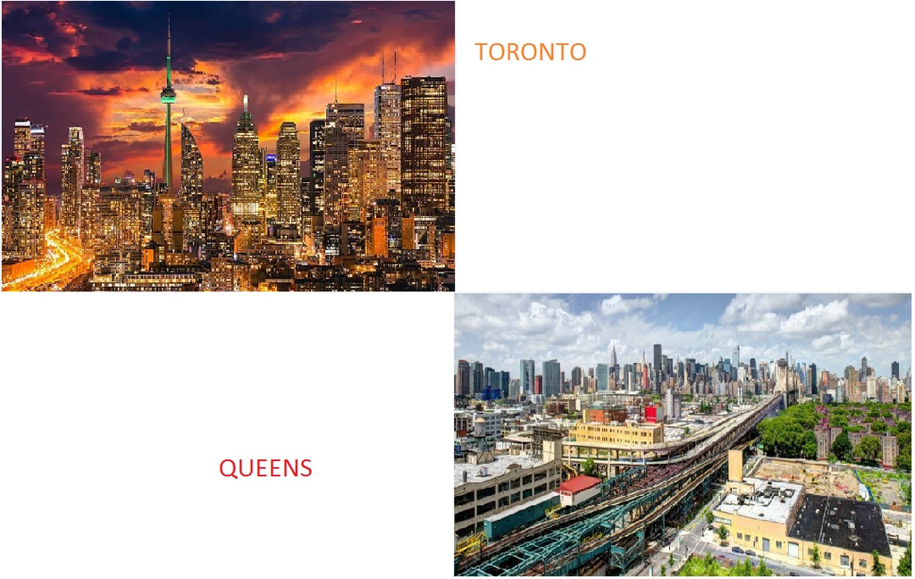

## Observation: Queens is a New York City borough on Long Island across the East River from Manhattan. It has a population of about 2.5million people, average age in 30s which is very much suited me. On the other hand, Toronto, the capital of the province of Ontario, is a major Canadian city along Lake Ontario’s northwestern shore. It's a dynamic metropolis with a core of soaring skyscrapers, all dwarfed by the iconic, free-standing CN Tower. Toronto also has many green spaces, from the orderly oval of Queen’s Park to 400-acre High Park and its trails, sports facilities and zoo. It also has population of about 3 million and average age group in 40s. Now, looking at this i wanted to find set of similarities and dissimilarities between the two cities using the help data already available online within in the First 5 Mile radius.